# Accessing the Chemical Elements Data from PubChem

PubChem provides the Periodic Table (https://pubchem.ncbi.nlm.nih.gov/periodic-table/) and Element Pages to help users navigate the abundant chemical element data available within PubChem. More detailed information on these services is provided in the following paper:

> **PubChem Periodic Table and Element Pages: Improving Access to Information on Chemical Elements from Authoritative Sources**  
> Kim et al., Chemistry Teacher International, 2021, 3(1):57-65.  
> DOI: 10.1515/cti-2020-0006

The data underlying the PubChem Periodic Table and Element Pages are freely available for download. This Jupyter notebook demonstrates how to download the properties of chemical elements and visualize the periodicity of those properties. The data used in this notebook can be downloaded from the PubChem Periodic Table (https://pubchem.ncbi.nlm.nih.gov/periodic-table/), by clicking the **DOWNLOAD** button and then the **CSV** button.

[figure not shown]

Alternatively, the data can also be downloaded using a python script, as demonstrated below. Here, we use a python data analysis library called pandas. Using pandas, we can directly load the data from the web into a data frame.

```python
import requests
import pandas as pd
```

```python
url = "https://pubchem.ncbi.nlm.nih.gov/rest/pug/periodictable/CSV"
df = pd.read_csv(url)
```

```python
df
```

|  | AtomicNumber | Symbol | Name | AtomicMass | CPKHexColor | ElectronConfiguration | Electronegativity | AtomicRadius | IonizationEnergy | ElectronAffinity | OxidationStates | StandardState | MeltingPoint | BoilingPoint | Density | GroupBlock | YearDiscovered |
| --- | --- | --- | --- | --- | --- | --- | --- | --- | --- | --- | --- | --- | --- | --- | --- | --- | --- |
| 0 | 1 | H | Hydrogen | 1.008000 | FFFFFF | 1s1 | 2.20 | 120.0 | 13.598 | 0.754 | +1, -1 | Gas | 13.81 | 20.28 | 0.000090 | Nonmetal | 1766 |
| 1 | 2 | He | Helium | 4.002600 | D9FFFF | 1s2 | NaN | 140.0 | 24.587 | NaN | 0 | Gas | 0.95 | 4.22 | 0.000179 | Noble gas | 1868 |
| 2 | 3 | Li | Lithium | 7.000000 | CC80FF | [He]2s1 | 0.98 | 182.0 | 5.392 | 0.618 | +1 | Solid | 453.65 | 1615.00 | 0.534000 | Alkali metal | 1817 |
| 3 | 4 | Be | Beryllium | 9.012183 | C2FF00 | [He]2s2 | 1.57 | 153.0 | 9.323 | NaN | +2 | Solid | 1560.00 | 2744.00 | 1.850000 | Alkaline earth metal | 1798 |
| 4 | 5 | B | Boron | 10.810000 | FFB5B5 | [He]2s2 2p1 | 2.04 | 192.0 | 8.298 | 0.277 | +3 | Solid | 2348.00 | 4273.00 | 2.370000 | Metalloid | 1808 |
| ... | ... | ... | ... | ... | ... | ... | ... | ... | ... | ... | ... | ... | ... | ... | ... | ... | ... |
| 113 | 114 | Fl | Flerovium | 290.192000 | NaN | [Rn]7s2 7p2 5f14 6d10 (predicted) | NaN | NaN | NaN | NaN | 6, 4,2, 1, 0 | Expected to be a Solid | NaN | NaN | NaN | Post-transition metal | 1998 |
| 114 | 115 | Mc | Moscovium | 290.196000 | NaN | [Rn]7s2 7p3 5f14 6d10 (predicted) | NaN | NaN | NaN | NaN | 3, 1 | Expected to be a Solid | NaN | NaN | NaN | Post-transition metal | 2003 |
| 115 | 116 | Lv | Livermorium | 293.205000 | NaN | [Rn]7s2 7p4 5f14 6d10 (predicted) | NaN | NaN | NaN | NaN | +4, +2, -2 | Expected to be a Solid | NaN | NaN | NaN | Post-transition metal | 2000 |
| 116 | 117 | Ts | Tennessine | 294.211000 | NaN | [Rn]7s2 7p5 5f14 6d10 (predicted) | NaN | NaN | NaN | NaN | +5, +3, +1, -1 | Expected to be a Solid | NaN | NaN | NaN | Halogen | 2010 |
| 117 | 118 | Og | Oganesson | 295.216000 | NaN | [Rn]7s2 7p6 5f14 6d10 (predicted) | NaN | NaN | NaN | NaN | +6, +4, +2, +1, 0, -1 | Expected to be a Gas | NaN | NaN | NaN | Noble gas | 2006 |

118 rows × 17 columns

```python
df.shape      # Check the dimension of the data frame (the number of rows, the number of columns)
```

```
(118, 17)
```

```python
df.columns    # Check the available information.
```

```
Index(['AtomicNumber', 'Symbol', 'Name', 'AtomicMass', 'CPKHexColor',
       'ElectronConfiguration', 'Electronegativity', 'AtomicRadius',
       'IonizationEnergy', 'ElectronAffinity', 'OxidationStates',
       'StandardState', 'MeltingPoint', 'BoilingPoint', 'Density',
       'GroupBlock', 'YearDiscovered'],
      dtype='object')
```

In some charts generated in this notebook, data will be color-coded using the information on the period of an element (i.e., the row on the periodic table where an element appears). However, as shown in the above code cell, this information is not available in the data frame. Therefore, we add it to the data frame.

```python
Period = [None] * 118

for i in range(0,len(Period)):

    an =i + 1             # Atomic number

    if (1 <= an) & (an <= 2) :
        Period[i] = "Period 1"
    elif (3 <= an) & (an <= 10) :
        Period[i] = "Period 2"
    elif (11 <= an) & (an <= 18) :
        Period[i] = "Period 3"
    elif (19 <= an) & (an <= 36) :
        Period[i] = "Period 4"
    elif (37 <=an ) & (an <= 54) :
        Period[i] = "Period 5"
    elif (55 <= an) & (an <= 86) :
        Period[i] = "Period 6"
    elif (87 <= an) & (an <= 118) :
        Period[i] = "Period 7"
```

```python
df["Period"] = Period
```

Now let's import matplotlib and seaborn for data visualization.

```python
import matplotlib.pyplot as plt
import seaborn as sns
```

```python
sns.set_style("darkgrid")
```

## 1. Atomic Mass

```
[Text(0, 0.5, 'Atomic Mass')]
```

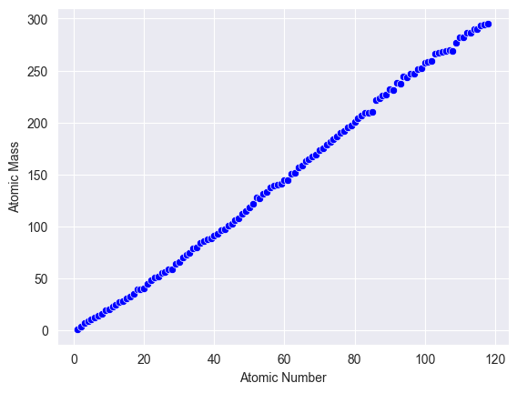

```python
ax=sns.scatterplot(x=df.AtomicNumber, y=df.AtomicMass, color='Blue')
ax.set(xlabel='Atomic Number')
ax.set(ylabel='Atomic Mass')
```

## 2. Ionization Energy, Electron Affinity & Electronegativity

Now we want to look into the periodicity of the ionization energy, electron affinity, and electronegativity among the chemical elements. These properties are not known for some elements, especially for elements heavier than Lr (Atomic Number=103), as identified in the following code cell.

```python
df[(df.IonizationEnergy.isnull()) & (df.ElectronAffinity.isnull()) & (df.Electronegativity.isnull())][['AtomicNumber', 'Symbol','IonizationEnergy','ElectronAffinity','Electronegativity']]
```

|  | AtomicNumber | Symbol | IonizationEnergy | ElectronAffinity | Electronegativity |
| --- | --- | --- | --- | --- | --- |
| 103 | 104 | Rf | NaN | NaN | NaN |
| 104 | 105 | Db | NaN | NaN | NaN |
| 105 | 106 | Sg | NaN | NaN | NaN |
| 106 | 107 | Bh | NaN | NaN | NaN |
| 107 | 108 | Hs | NaN | NaN | NaN |
| 108 | 109 | Mt | NaN | NaN | NaN |
| 109 | 110 | Ds | NaN | NaN | NaN |
| 110 | 111 | Rg | NaN | NaN | NaN |
| 111 | 112 | Cn | NaN | NaN | NaN |
| 112 | 113 | Nh | NaN | NaN | NaN |
| 113 | 114 | Fl | NaN | NaN | NaN |
| 114 | 115 | Mc | NaN | NaN | NaN |
| 115 | 116 | Lv | NaN | NaN | NaN |
| 116 | 117 | Ts | NaN | NaN | NaN |
| 117 | 118 | Og | NaN | NaN | NaN |

Therefore, let's make a new data frame that does not have those elements without the Ionization energy, electron affinity, and electronegativity data.

```python
df_tmp = df.dropna(axis=0, how='all', subset=['IonizationEnergy','ElectronAffinity','Electronegativity'])
```

```python
df_tmp.shape
```

```
(103, 18)
```

### 2.1. Ionization Potential

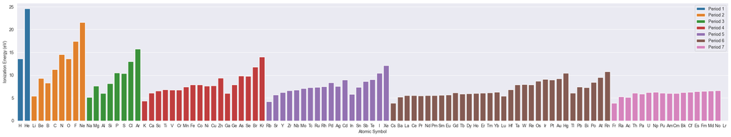

```python
plt.figure(figsize=(30,5))
ax=sns.barplot(data=df_tmp, x="Symbol", y="IonizationEnergy", hue="Period", dodge=False)
ax.set(xlabel="Atomic Symbol", ylabel="Ionization Energy (eV)")
plt.legend(loc='upper right');
```

### 2.2. Electron Affinity

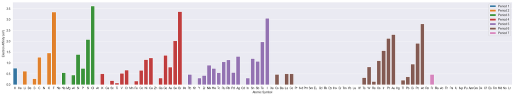

```python
plt.figure(figsize=(30,5))
ax=sns.barplot(data=df_tmp, x="Symbol", y="ElectronAffinity", hue="Period", dodge=False)
ax.set(xlabel="Atomic Symbol", ylabel="Electron Affinity (eV)")
plt.legend(loc='upper right');
```

### 2.3. Electronegativity

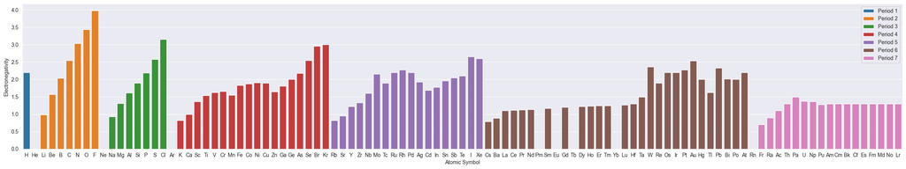

```python
plt.figure(figsize=(30,5))
ax=sns.barplot(data=df_tmp, x="Symbol", y="Electronegativity", hue="Period", dodge=False)
ax.set(xlabel="Atomic Symbol", ylabel="Electronegativity")
plt.legend(loc='upper right');
```

### 2.4. Comparison between Ionization Energy, Electron Affinity, and Electronegativity

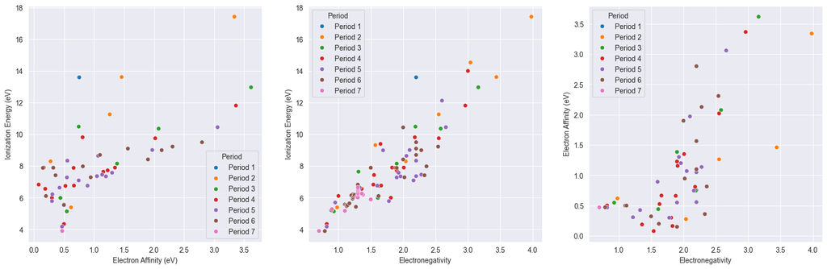

```python
fig, axs = plt.subplots(ncols=3,figsize=(20,6))

sns.scatterplot(data=df_tmp, x="ElectronAffinity", y="IonizationEnergy", hue="Period", ax=axs[0])
axs[0].set(xlabel="Electron Affinity (eV)", ylabel="Ionization Energy (eV)")

sns.scatterplot(data=df_tmp, x="Electronegativity", y="IonizationEnergy", hue="Period", ax=axs[1])
axs[1].set(xlabel="Electronegativity", ylabel="Ionization Energy (eV)")

sns.scatterplot(data=df_tmp, x="Electronegativity", y="ElectronAffinity", hue="Period", ax=axs[2])
axs[2].set(xlabel="Electronegativity", ylabel="Electron Affinity (eV)");
```

## 3. Melting Point and Boiling Point

Now let's visualize the melting and boiling points of chemical elements. These data are not available for all compounds, so we want to exclude those elements without the necessary data.

```python
df[(df.MeltingPoint.isnull()) & (df.BoilingPoint.isnull())][['AtomicNumber', 'Symbol','MeltingPoint','BoilingPoint']]
```

|  | AtomicNumber | Symbol | MeltingPoint | BoilingPoint |
| --- | --- | --- | --- | --- |
| 103 | 104 | Rf | NaN | NaN |
| 104 | 105 | Db | NaN | NaN |
| 105 | 106 | Sg | NaN | NaN |
| 106 | 107 | Bh | NaN | NaN |
| 107 | 108 | Hs | NaN | NaN |
| 108 | 109 | Mt | NaN | NaN |
| 109 | 110 | Ds | NaN | NaN |
| 110 | 111 | Rg | NaN | NaN |
| 111 | 112 | Cn | NaN | NaN |
| 112 | 113 | Nh | NaN | NaN |
| 113 | 114 | Fl | NaN | NaN |
| 114 | 115 | Mc | NaN | NaN |
| 115 | 116 | Lv | NaN | NaN |
| 116 | 117 | Ts | NaN | NaN |
| 117 | 118 | Og | NaN | NaN |

The elements with an atomic number greater than 103 do not have melting and boiling point data. Therefore, we want to exclude those elements by using the `df_tmp` data frame, which was used previously to create the charts for the ionization potential, electron affinity, and electronegativity.

### 3.1. Melting Point

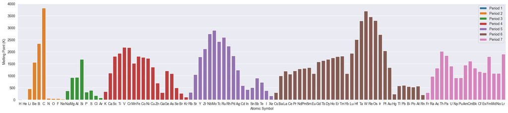

```python
plt.figure(figsize=(25,5))
ax=sns.barplot(data=df_tmp, x="Symbol", y="MeltingPoint", hue="Period", dodge=False)
ax.set(xlabel="Atomic Symbol", ylabel="Melting Point (K)")
plt.legend(loc='upper right');
```

### 3.2. Boiling Point

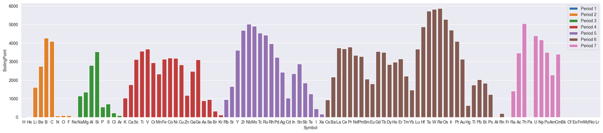

```python
plt.figure(figsize=(25,5))
sns.barplot(data=df_tmp, x="Symbol", y="BoilingPoint", hue="Period", dodge=False)
ax.set(xlabel="Atomic Symbol", ylabel="Boiling Point (K)")
plt.legend(loc='upper right');
```

### 3.3. Comparison between Melting and Boiling Points

[figure not shown]

```python
plt.figure(figsize=(6,6))
ax=sns.scatterplot(data=df, x="MeltingPoint", y="BoilingPoint", hue="Period")
ax.set(xlabel="Boiling Point (K)", ylabel="Melting Point (K)");
```

## 4. Density

Now let's look into the density of chemical elements. The density data used here are measured at STP (standard temperature and pressure, 0 °C and 1 atm).

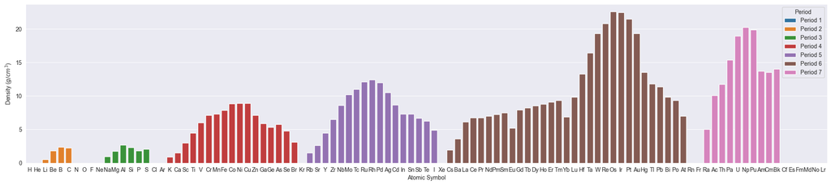

```python
plt.figure(figsize=(25,5))
ax=sns.barplot(data=df_tmp, x="Symbol", y="Density", hue="Period", dodge=False)   # Use df_tmp to exclude the elements without relevant data.
ax.set(xlabel="Atomic Symbol", ylabel="Density ($g/cm^{3}$)");
```

Some elements have very small density values, less than 0.5 g/cm<sup>3</sup>. This is also shown in the following histogram.

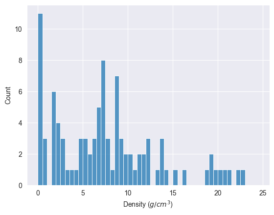

```python
import numpy as np

bins=np.arange(0,25,0.5).tolist()    # list from 0 to 25 with an increment of 0.5
ax = sns.histplot(data=df_tmp, x='Density', bins=bins)
ax.set(xlabel="Density ($g/cm^{3}$)");
```

```python
df_tmp[ df_tmp.Density < 0.5 ][['AtomicNumber','Symbol','Density','StandardState']]
```

|  | AtomicNumber | Symbol | Density | StandardState |
| --- | --- | --- | --- | --- |
| 0 | 1 | H | 0.000090 | Gas |
| 1 | 2 | He | 0.000179 | Gas |
| 6 | 7 | N | 0.001251 | Gas |
| 7 | 8 | O | 0.001429 | Gas |
| 8 | 9 | F | 0.001696 | Gas |
| 9 | 10 | Ne | 0.000900 | Gas |
| 16 | 17 | Cl | 0.003214 | Gas |
| 17 | 18 | Ar | 0.001784 | Gas |
| 35 | 36 | Kr | 0.003733 | Gas |
| 53 | 54 | Xe | 0.005887 | Gas |
| 85 | 86 | Rn | 0.009730 | Gas |

All these elements with densities < 0.5 g/cm<sup>3</sup> exist as gas at STP.